## Approximation Methods

### Approximations based on Taylor’s Theorem

Say we have a r.v. X with density f, a function h and we want to know Var(h(X)). Of course by definition we have

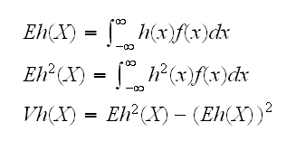

but sometimes these integrals (sums) are very difficult to evaluate. In this section we discuss some methods for approximating the variance.

There are various formulas for the remainder term, but we won’t need them here.

#### **Example**

say h(x) = log(x+1) and we want to approximate h at x=0. Then we have

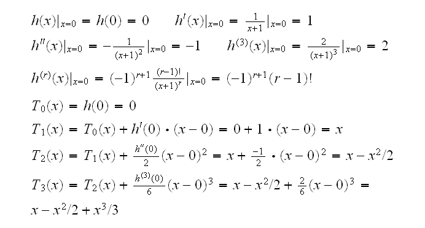

The approximation is illustrated here:

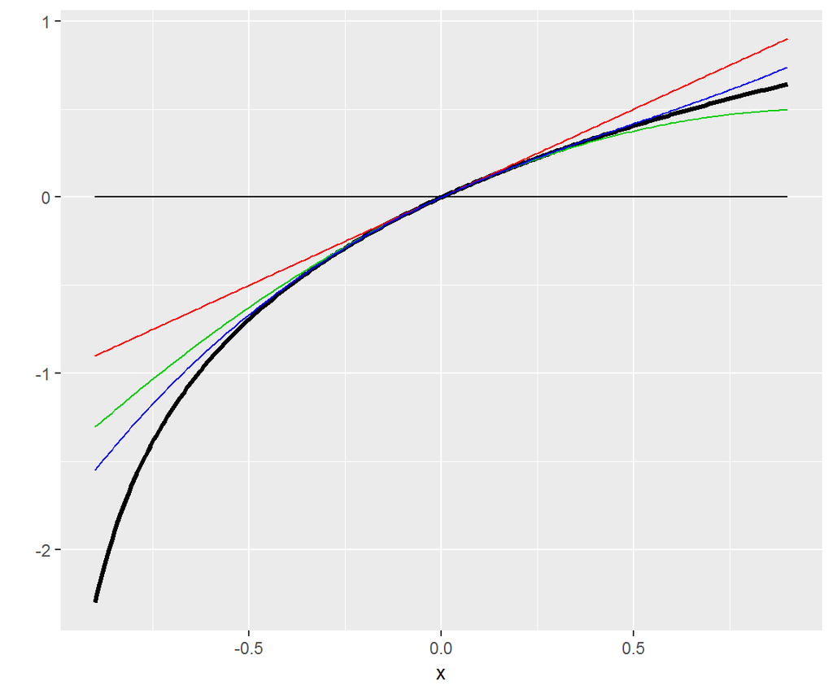

```r
a <- 0; r <- 3
x <- seq(-0.9, 0.9, length = 250)
h <- rep(0, r+1)
h[1] <- log(a+1)
for (n in 1:r) h[n+1] <- (-1)^(n+1)/n/(a+1)^n
y <- matrix(0, 250, r+1)
y[, 1] <- rep(log(a+1), 250)
for (k in 1:r) y[ , k+1] <- y[, k] + h[k+1]*(x-a)^k
df <- data.frame(x=x, ly=log(x+1))
plt <- ggplot(df, aes(x, ly)) +
        geom_line(size=1.2) + ylab("")

for (k in 1:(r + 1))
  plt <- plt +
    geom_line(data=data.frame(x=x, y=y[, k]), aes(x, y), color=k)
plt
```

One application of this is the

### Delta Method

Let Y<sub>n</sub> be a sequence of rv’s that satisfies

$$\sqrt{n}(Y_n - \theta) \rightarrow N(0, \sigma)$$

in distribution. For a given function g and a specific value of $\theta$, suppose that $g'(\theta)$ exist and and is not 0. Then

$$\sqrt{n}\left(g(Y_n) - g(\theta)\right) \rightarrow N(0, \sigma g'(\theta))$$

**proof**

the Taylor expansion of $g(Y_n)$ around $Y_n=\theta$ is

$g(Y_n )=g( \theta )+g'( \theta )(Y_n - \theta )+R$

where $R \rightarrow 0$ as $Y_n \rightarrow \theta$. Now

$\sqrt{n}[g(Y_n)-g(\theta) ] =$

$\sqrt{n}[g( \theta )+g'( \theta )(Y_n - \theta )+R-g( \theta) ] =$

$g'( \theta )\sqrt{n}(Y_n - \theta )+\sqrt{n}R \rightarrow g'( \theta )X$

where $X \sim N(0,\sigma)$

#### **Example**

say $X_1, ..,X_n$ iid Exp(1), so EX=VarX=1, then by the CLT

$\sqrt{n} (\bar{X} -1) \rightarrow N(0,1)$

Let g(x)=x<sup>p</sup>, so g’(x)=px<sup>p-1</sup> and by the delta method

$\sqrt{n}( \bar{X}^p-1) \rightarrow N(0,p)$

```r
n <- 100; p <- 2; B <- 10000
x <-  matrix(rexp(n*B, 1), ncol=n)
xbar <- apply(x, 1, mean)
print(mean(xbar))
```

```
## [1] 1.000401
```

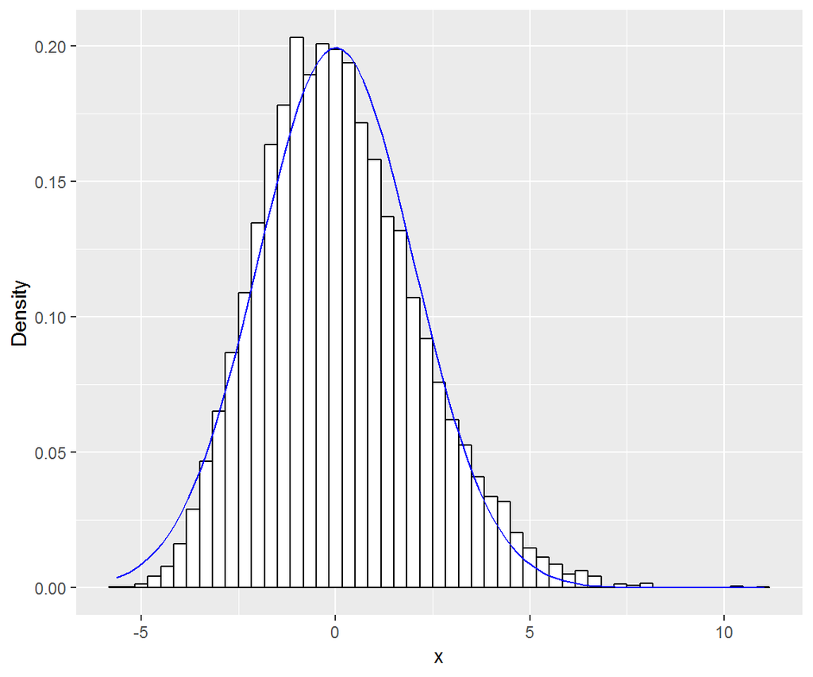

```r
y <- sqrt(n)*(xbar^p-1)
bw <- diff(range(y))/50
df <- data.frame(x=y)
ggplot(df, aes(x)) +
  geom_histogram(aes(y = ..density..),
    color = "black",
    fill = "white",
    binwidth = bw) +
    labs(x = "x", y = "Density") +
  stat_function(fun = dnorm,
                colour = "blue",
                args=list(mean=0, sd=p))
```

say we have a sequence of iid rv’s $X_1, ..,X_n$, each with mean $\mu \ne 0$ and standard deviation $\sigma$. We know from the law of large numbers that

$\sqrt{n}(\bar{X} -\mu) \rightarrow N(0,\sigma)$

Now let g(x)=1/x, then g’(x)=-1/x<sup>2</sup> and we get

$\sqrt{n}(1/\bar{X} -1/\mu) \rightarrow N(0,\sigma/\mu^2)$

say for example $X_i\sim U[0,1]$, then $\mu=1/2$ and $\sigma=1/ \sqrt{12}$, so according to the delta method

$\sqrt{n}(1/ \bar{X} -1/ \mu ) \sim N(0, \sigma / \mu^2) = N(0,2/ \sqrt{3})$

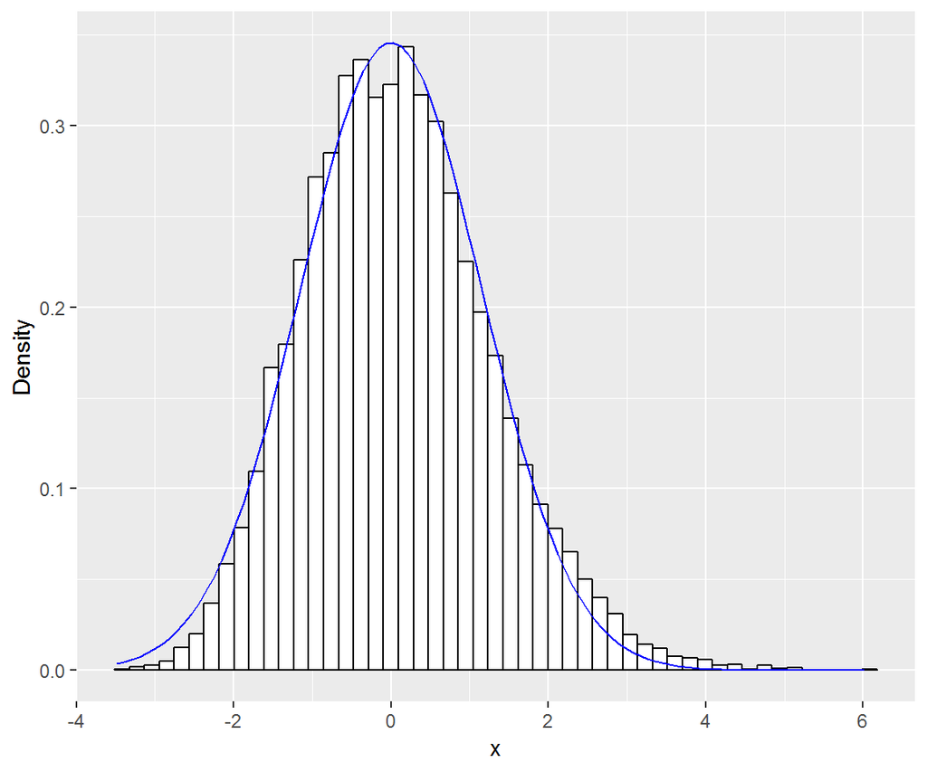

```r
n <- 100; B <- 10000
x <-  matrix(runif(n*B), ncol=n)
xbar <- apply(x, 1, mean)
y <- sqrt(n)*(1/xbar - 1/0.5)
bw <- diff(range(y))/50
df <- data.frame(x=y)
ggplot(df, aes(x)) +
  geom_histogram(aes(y = ..density..),
    color = "black",
    fill = "white",
    binwidth = bw) +
    labs(x = "x", y = "Density") +
  stat_function(fun = dnorm,
                colour = "blue",
                args=list(mean=0, sd=2/sqrt(3)))
```

The first order Taylor expansion of h about **$\mu$** is

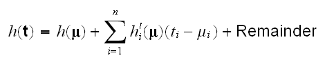

Forgetting about the remainder we have

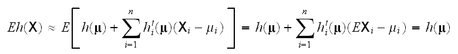

and

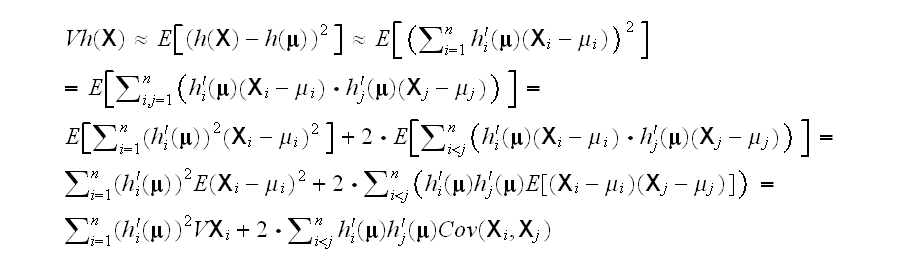

#### **Example**

```r
var(log(rnorm(10000, 10)))
```

```
## [1] 0.01037499
```

#### **Example**

Say we have two rv’s X and Y and $X \perp Y$, then the formula simplifies to

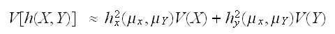

say X and Y have a geometric distribution with parameters p and r, respectively. We want to approximate the variance of $\sqrt{X^2+Y^2}$

Now $\mu_X=1/p, V[X]=(1-p)/p^2, \mu_Y=1/r, V[Y]=(1-r)/r^2$

let $h(x,y)= \sqrt{x^2+y^2}$, then

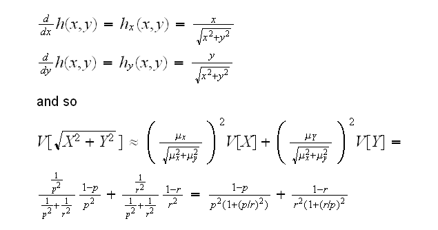

```r
p <- 0.2; r <- 0.3; B <- 10000
x <- rgeom(B, p)+1
y <- rgeom(B, r)+1
round(c(var(sqrt(x^2+y^2)),
  (1-p)/(p^2*(1+(p/r)^2))+(1-r)/(r^2*(1+(r/p)^2))), 3)
```

```
## [1] 19.782 16.239
```

#### **Example**

say we have a sample X<sub>1</sub>, ..,X<sub>n</sub> from a Bernoulli r.v. with success parameter p, that is P(X=1)=p=1-P(X=0). One popular measure of the probability of winning a game is the odds p/(1-p). For example when you roll a fair die the odds of getting a six are (1/6)/(1-(1/6) = 1:5.

An obvious estimator for p is $\hat{p}$, the sample mean, or here the proportion of “successes” in the n trials. Then an obvious estimator for the odds is $\hat{p}/(1-\hat{p})$. The question is, what is the variance of this estimator?

First note that

$$\begin{aligned}
&Var[\hat{p}] = = \\
&Var[1/n \sum X_i] = \\
&1/n^2 \sum V[X_i] = \\
&1/nV[ X_1 ]=\\
&p(1-p)/n
\end{aligned}$$
Using the above approximation we get the following: let h(p)=p/(1-p), so h’(p)=1/(1-p)<sup>2</sup> and

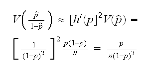

```r
p <- 0.25; n <- 25; B <- 10000
x <- matrix(rbinom(B, 1, p), ncol=n)
phat <- apply(x, 1, mean)
odds <- phat/(1 - phat)
round(c(var(odds), p/n/(1 - p)^3), 4)
```

```
## [1] 0.0271 0.0237
```

#### **Example**

Let’s try to solve this problem analytically. First, log(x!) is an increasing function of x, so there exists x<sub>50</sub> such that

log(x!)>50 iff x>x<sub>50</sub>

so that $P(\log(X!)>50)=P(X\ge x_{50})$. Finding x<sub>50</sub> analytically is hopeless, though. We can do it with R by trial and error, using *log(factorial(n))* for different values of n. We find n=22.5, so

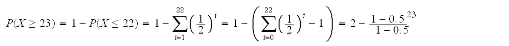

or about $2.38\times 10^{-7}$

How about an R check? The problem with this is that the probability p we want to find is very small, so in a simple simulation we can expect the outcome of interest only about every 1 in 4.2 million runs. In order to get some reasonably good estimate we probably need to run the simulation with n=10<sup>9</sup>.

Here is a strange idea: the problem is that our event of interest, log(X!)>50, is very rare, it almost never happens. Let’s instead sample from a distribution Y which has large values much more often, so that log(Y!)>50 happens more often. For example, let’s try Y geometric with p=0.05:

```r
B <- 100000
y <- rgeom(B, 0.05)+1
sum(log(factorial(y))>50)/B
```

```
## Warning in factorial(y): value out of range in 'gammafn'
```

```
## [1] 0.32328
```

It seems P(log(Y!)>50)=0.32, but there is a problem, we get a warning from R: **value out of range in ‘gammafn’**. The reason is that R calculates log(y!) by first calculating y! and then taking log, and it finds y! via the gamma function, but for y bigger than about 170 y! can no longer be found that way. But log(175!)=732.33, not so big at all. The routine logfac is based on on Stirling’s’ approximation:

```r
logfac <- function(n)
  ifelse(n<20, log(factorial(n)),
          0.918938533+(n+0.5)*log(n)-n+(1/12-1/(360*n^2))/n)
```

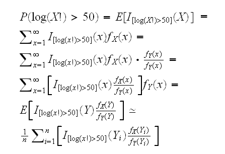

so if we sample from Y and find the sum here we still get an estimate of the probability for X. This is done here:

```r
y <- y[logfac(y) >= 50]
w <- dgeom(y-1, 0.5)/dgeom(y-1, 0.05)
sum(w)/B
```

```
## [1] 2.37628e-07
```

In general we have the following: Let X be a rv’ with pdf f and and Y a rv’ with pdf g. Say we want to find E[h(X)]. Then

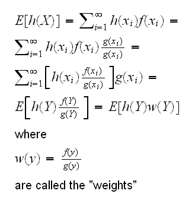

**Note** this was done for discrete rv’s but it works just as well for continuous ones.

**Note** how to choose Y? Obviously we need Y such that it can’t happen that P(Y=x)>0 and P(X=x)=0. In general we should choose a Y with the same “support” as X, that is P(X=x)>0 iff P(Y=x)>0. It is not necessary to have a Y that “looks like” X. For example in the case above we could have choosen Y with pdf

$f_Y(x)=6/(\pi^2 x^2)$

It is also a good idea to choose Y such that the event of interest (log(Y!)>50) happens about 50% of the time.

#### **Example**

say X, Y and Z have a standard normal distribution. Find P(|XYZ|>K), for example K=10.

Now there is no way to do this analytically, and again the probability is very small. So we will use IS with X’, Y’ and Z’ generated from normal distributions with mean 0 and standard deviation s. For our case of K=10 s=3 works good. In general, for some K play around a bit to find a good s.

```r
B <- 10000; s=3
x <- rnorm(B, 0, s)
y <- rnorm(B, 0, s)
z <- rnorm(B, 0, s)
T <- abs(x*y*z)
I <- c(1:B)[T > 10]
print(length(I)/B)
```

```
## [1] 0.3519
```

```r
w <- dnorm(x[I])/dnorm(x[I], 0, s) *
     dnorm(y[I])/dnorm(y[I], 0, s) *
     dnorm(z[I])/dnorm(z[I], 0, s)
sum(w)/B
```

```
## [1] 0.0003698837
```